# Zadání zápočtové úlohy

2025-06-05

## Instrukce

Zpracujte přiložená syntetická data obsahující informace o státnicových okruzích v oboru Aplikovaná informatika (předměty KI/SZZTP, KI/SZZPP, KI/SZZVP) a o volbách otázek jednotlivými studenty. Pro účely této práce byla připravena syntetická data.

- Data zpracujte dle zadání.
- **Při práci se soubory využívejte vždy relativní cestu k souboru (relativní vůči umístění zdrojového kódu)**
- Vytvořte dle vlastní volby vhodné vizualizace dat.
- Svůj postup popište a výsledky stručně slovně vyhodnoťte.
- Vypracujte Quarto report (nebo R Notebook) zobrazující nejen grafy a tabulky, ale také textový popis řešení.
- **Výsledný dokument ve formátu html nahrajte spolu se zdrojovými kódy (jednak R a jednak qmd včetně složek v případě Quarto reportu, nebo rmd v případě R Notebooku) na stránky předmětu v systému** [**Moodle**](https://moodle.prf.ujep.cz/course/view.php?id=932) (neváhejte nahrát celou pracovní složku včetně zdrojových dat).

K vypracování se doporučuje využití následujících knihoven:

```r
library(readxl)
library(dplyr)
library(ggplot2)
library(tidyr)
```

## Úkol 1

Státní závěrečná zkouška KI v oboru Aplikovaná informatika sestává ze tří bloků:

- KI/SZZTP: Teoretické základy informatiky
- KI/SZZPP: Aplikovaná informatika – povinný základ
- KI/SZZVP: Aplikovaná informatika – volitelné bloky

Každý blok obsahuje seznam číslovaných okruhů. Studenti si z každého bloku volí jen určitý počet okruhů, ze kterých si pak budou u zkoušky losovat.

Vaším úkolem je zpracovat výběry studentů – připravte pro každého studenta tři tabulky (jednu pro každý blok), které budou obsahovat:

- Název okruhu
- Číslo okruhu v plném seznamu
- Číslo okruhu v redukovaném seznamu (zkráceném na vybrané otázky)

Vizualizace by měla odpovídat vzoru:

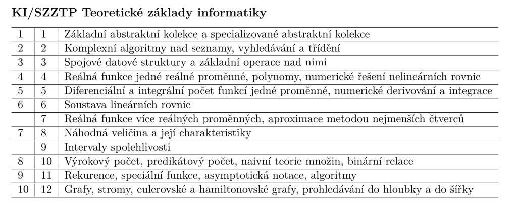

## Úkol 2

Na základě výběrů studentů zjistěte, které okruhy jsou v jednotlivých blocích nejméně oblíbené – tedy které otázky byly studenty nejméně často vybrány.

Pro každý blok (KI/SZZTP, KI/SZZPP, KI/SZZVP) spočítejte:

- Kolikrát byl každý okruh vybrán
- Seznam 5 nejméně vybíraných okruhů

Výsledek své analýzy zobrazte do vhodného grafu.